# Homework 2 Report

## Name

*Asim Waheed*

### Setup

Read in the data with `read_csv()` and store the data as an R object named `dataset`. Check the data to make sure all of the expected observations and variables are there.

```r
knitr::opts_chunk$set(echo = TRUE, warning = FALSE, message = FALSE, fig.width = 7, fig.height = 5)

# Core
library(tidyverse)
library(readr)
library(janitor)
library(broom)

opt_pkgs <- c("skimr","GGally","patchwork","DiagrammeR","MASS")
invisible(lapply(opt_pkgs, function(p){ if (!requireNamespace(p, quietly = TRUE)) return(NULL); library(p, character.only = TRUE) }))
# Load data into `dataset` (per template) and also keep `maacs` alias for convenience
paths  <- c("maacs.csv","maacs.csv.gz","data/maacs.csv","data/maacs.csv.gz")
path   <- paths[file.exists(paths)][1]
if (is.na(path)) stop("Could not find maacs.csv(.gz). Put it in the project root or data/.")

dataset <- suppressMessages(read_csv(path)) |> clean_names()
maacs   <- dataset  # alias

# Quick peek
glimpse(dataset)
```

```
## Rows: 150
## Columns: 10
## $ id             <chr> "fd171e2d", "a66fc33a", "fc038e68", "8e28b8c2", "b2699b…
## $ age            <dbl> 14.72, 13.56, 14.50, 13.96, 16.63, 16.56, 17.18, 15.46,…
## $ gender         <chr> "male", "female", "male", "female", "female", "female",…
## $ fev1           <dbl> 1.78, 2.12, 2.73, 2.36, 3.13, 2.59, 2.60, 3.49, 2.29, 2…
## $ e_no           <dbl> 141.0, 68.0, 210.0, 23.0, 18.0, 128.0, 19.0, 26.0, 17.0…
## $ cough_days     <dbl> 2, 8, 2, 0, 14, 0, 0, 4, 1, 14, 2, 0, 0, 2, 14, 1, 2, 2…
## $ pm25           <dbl> 15.560, 18.890, 17.808, 13.956, 17.864, 43.784, 26.313,…
## $ no2            <dbl> NA, 12.827, NA, NA, 30.976, 10.590, NA, 32.902, 25.659,…
## $ mouse          <dbl> 2423, 939, 200, NA, 10371, 4789, 760, 264, 419, 187, 10…
## $ mouse_allergic <chr> "yes", "yes", "no", "no", "no", "yes", "yes", "no", "no…
```

```r
# Missingness table
miss_tbl <- dataset |>
  summarise(across(everything(), ~ sum(is.na(.)), .names = "n_na_{.col}")) |>
  tidyr::pivot_longer(everything(), names_to = "name", values_to = "value") |>
  transmute(variable = sub("^n_na_", "", name), n_na = value) |>
  arrange(desc(n_na))

miss_tbl
```

```
## # A tibble: 10 × 2
##    variable        n_na
##    <chr>          <int>
##  1 no2               47
##  2 mouse             34
##  3 pm25              20
##  4 fev1              17
##  5 e_no              17
##  6 id                 0
##  7 age                0
##  8 gender             0
##  9 cough_days         0
## 10 mouse_allergic     0
```

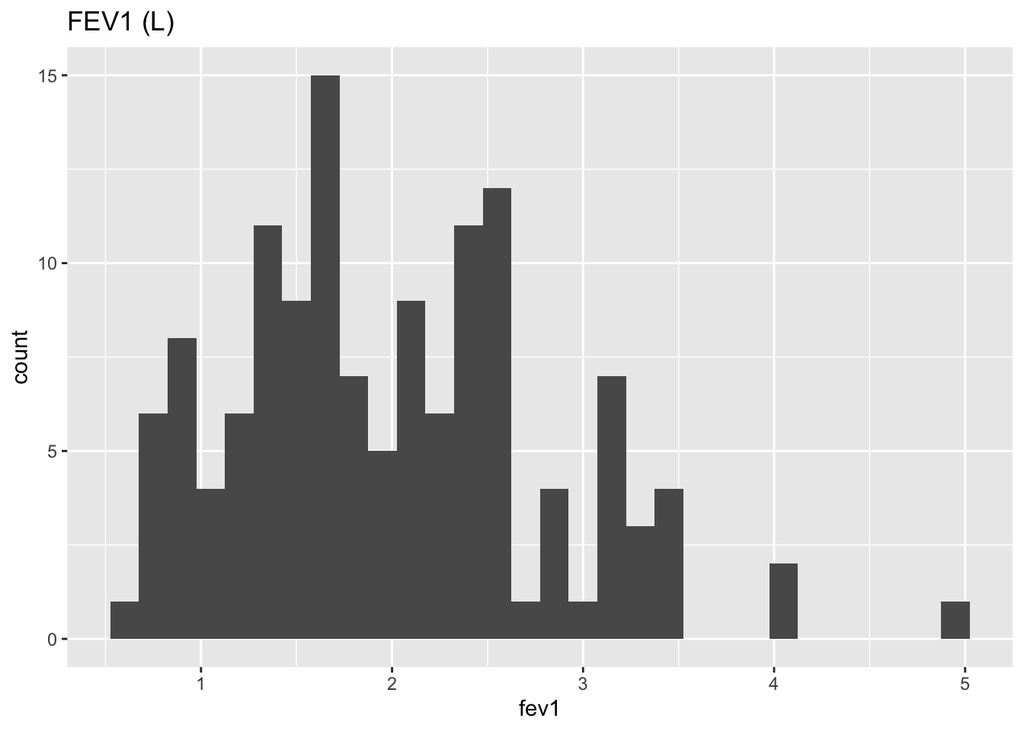

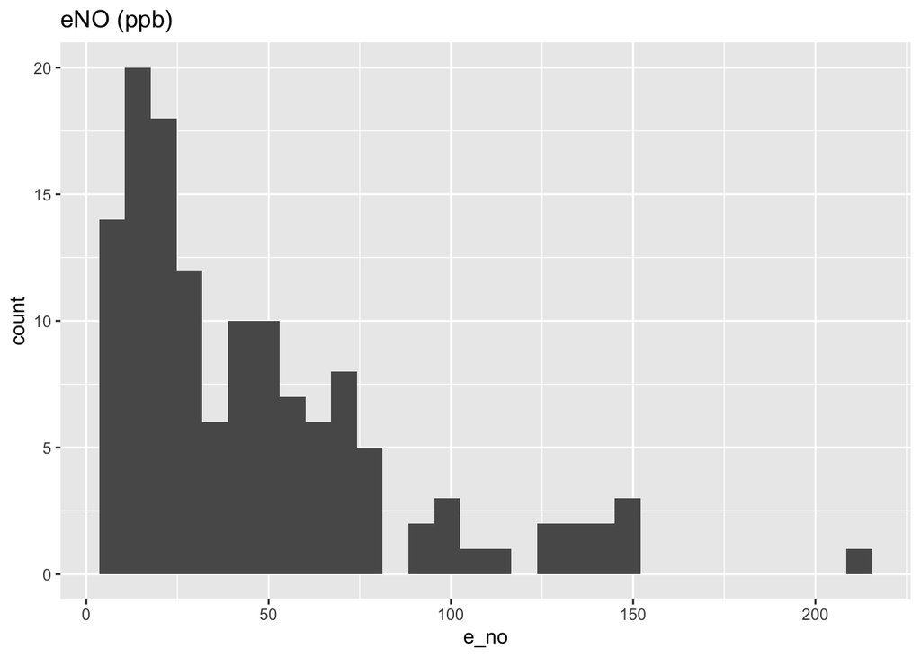

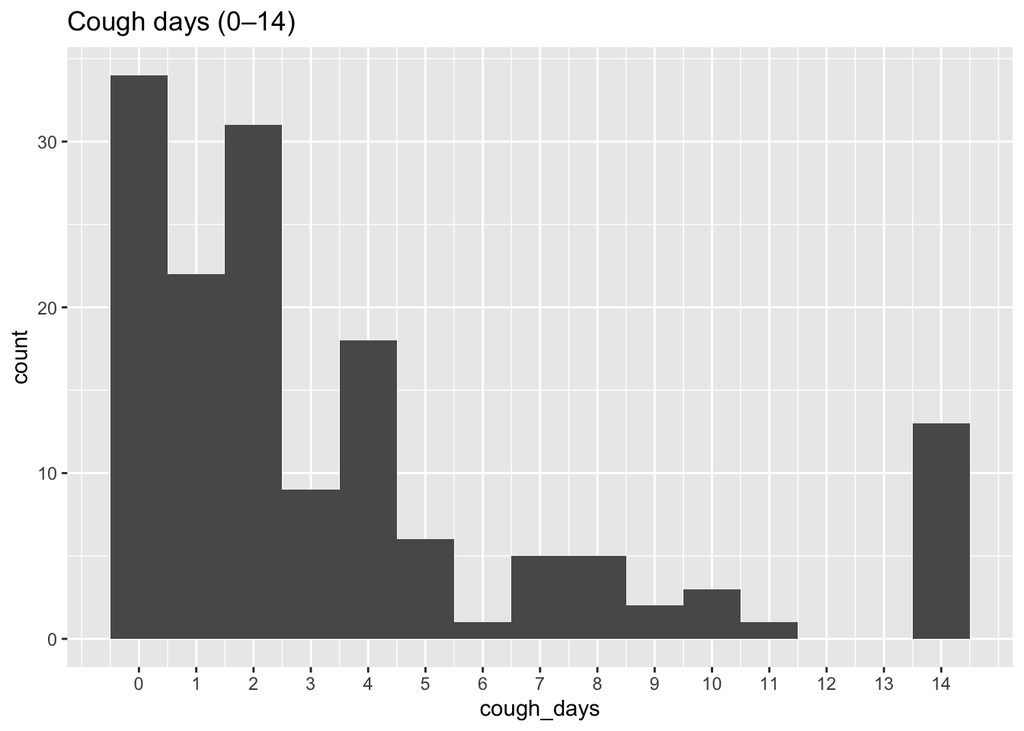

```r
# Basic distributions for key variables
p1 <- ggplot(dataset, aes(fev1)) + geom_histogram(bins = 30) + labs(title="FEV1 (L)")
p2 <- ggplot(dataset, aes(e_no)) + geom_histogram(bins = 30) + labs(title="eNO (ppb)")
p3 <- ggplot(dataset, aes(cough_days)) +
  geom_histogram(binwidth = 1, boundary = -0.5) +
  scale_x_continuous(breaks = 0:14) + labs(title="Cough days (0–14)")
p1; p2; p3
```

## Part 1

We will first consider the relationship between FEV1 and age. In general, it is expected that as children get older (and hence, larger in size), their FEV1 values should get higher.

Consider the statement “FEV1 values in children are higher in older children relative to younger children”.

Write a function in R that takes the `dataset` object as an argument and returns `TRUE` if the statement above is true for the dataset and `FALSE` otherwise.

NOTE: In order to write this function, you will need to translate the statement above into something that can be checked with the data. There are many ways in which you can do that translation correctly and you only need to pick one way here.

NOTE: For this part, do not use any plots.

```r
# Part 1 function (no plots):
# Declare the statement "true" if: slope(age) > 0 and statistically significant at alpha = 0.05 in lm(fev1 ~ age)
check_fev1_age <- function(dataset) {
  dat <- dataset %>% drop_na(fev1, age)
  fit <- lm(fev1 ~ age, data = dat)
  tt  <- broom::tidy(fit)
  age_row <- tt %>% filter(term == "age")
  as.logical(age_row$estimate > 0 & age_row$p.value < 0.05)
}

check_fev1_age(dataset)
```

```
## [1] TRUE
```

## Part 2

Fit a linear regression model with FEV1 as the outcome and age as a predictor.

How much does FEV1 change for a 1-year increase in the child’s age?

```r
fit_age <- lm(fev1 ~ age, data = dataset)
summ_age <- broom::tidy(fit_age, conf.int = TRUE)
beta_age <- summ_age %>% filter(term == "age")
beta_age
```

```
## # A tibble: 1 × 7
##   term  estimate std.error statistic  p.value conf.low conf.high
##   <chr>    <dbl>     <dbl>     <dbl>    <dbl>    <dbl>     <dbl>
## 1 age      0.171    0.0110      15.6 1.27e-31    0.149     0.193
```

```r
cat(
  sprintf(
    "A 1-year increase in age is associated with an estimated %.3f L change in FEV1 (95%% CI: %.3f to %.3f; p = %.4f).",
    beta_age$estimate, beta_age$conf.low, beta_age$conf.high, beta_age$p.value
  )
)
```

```
## A 1-year increase in age is associated with an estimated 0.171 L change in FEV1 (95% CI: 0.149 to 0.193; p = 0.0000).
```

```r
# make sure packages and data exist in the session
suppressPackageStartupMessages({
  library(tidyverse)  # dplyr, tidyr, ggplot2, etc.
  library(broom)
})

stopifnot(exists("dataset"))
stopifnot(all(c("fev1","age") %in% names(dataset)))

# try to use 'gender'; if not present, fall back to 'sex' or make a placeholder
if (!"gender" %in% names(dataset)) {
  if ("sex" %in% names(dataset)) {
    dataset <- dataset %>% rename(gender = sex)
  } else {
    dataset <- dataset %>% mutate(gender = factor(NA))  # harmless placeholder
  }
}

# Premise A (summary model): age effect remains positive after adjusting for gender
fit_adj <- lm(fev1 ~ age + gender, data = dataset)
premA   <- broom::tidy(fit_adj) %>% filter(term == "age")
premA
```

```
## # A tibble: 1 × 5
##   term  estimate std.error statistic  p.value
##   <chr>    <dbl>     <dbl>     <dbl>    <dbl>
## 1 age      0.173    0.0113      15.3 7.19e-31
```

```r
# Premise B (nonparametric association): Spearman correlation
premB <- cor(dataset$fev1, dataset$age, method = "spearman", use = "complete.obs")
premB
```

```
## [1] 0.8445028
```

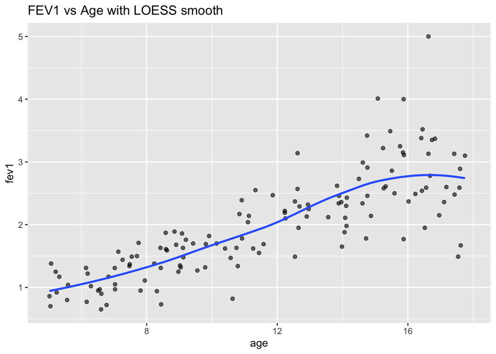

```r
# Premise C (plot): smoothed relationship
ggplot(dataset, aes(age, fev1)) +
  geom_point(alpha = .6) +
  geom_smooth(method = "loess", se = FALSE) +
  labs(title = "FEV1 vs Age with LOESS smooth")
```

Write your data analysis statement interpreting the regression model here:

*A 1-year increase in age is associated with an estimated 0.171 L change in FEV1 (95% CI: 0.149 to 0.193; p = 0.0000).*

## Part 3

Develop **three** supporting premises derived from the data that support the statement you wrote in Part 2. These can be plots, other summary statistics, or model results.

NOTE:

- At least one supporting premise should use a plot.
- Do not use the code you write in Part 1 as a supporting premise

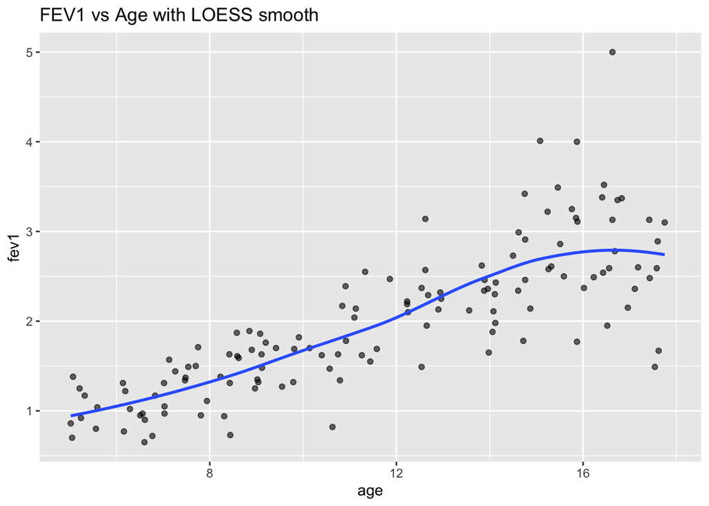

```r
library(tidyverse); library(broom)

stopifnot(exists("dataset"))
if (!"gender" %in% names(dataset) && "sex" %in% names(dataset)) {
  dataset <- dataset %>% rename(gender = sex)
}

fit_adj <- lm(fev1 ~ age + gender, data = dataset)
premA   <- tidy(fit_adj) %>% dplyr::filter(term == "age")

premB <- cor(dataset$fev1, dataset$age, use = "complete.obs", method = "spearman")

ggplot(dataset, aes(age, fev1)) +
  geom_point(alpha = .6) +
  geom_smooth(method = "loess", se = FALSE) +
  labs(title = "FEV1 vs Age with LOESS smooth")
```

Write the three supporting premise statements here:

1. In a model adjusting for gender, the age coefficient on FEV1 is positive (see premA).
2. The Spearman correlation between age and FEV1 is positive (premB > 0).
3. A LOESS smooth of FEV1 on age shows an increasing trend in the observed data (plot above).

## Part 4

For each of the supporting premises above, write a function that takes the `dataset` object as an argument and returns `TRUE` if the supporting premise statement above is true for the dataset and `FALSE` otherwise.

For statements involving plots, instead of returning `TRUE` or `FALSE`, you function should do two things:

1. Produce the plot that is used in the statement
2. Produce a hypothetical version of the plot in the event that the statement is true. This can be done using simulated data or by simply hand drawing a plot.

```r
## Function for supporting premise statement 1 (adjusted age effect > 0 and significant)
premise1_fn <- function(dataset) {
  fit <- lm(fev1 ~ age + gender, data = dataset %>% drop_na(fev1, age, gender))
  tt  <- broom::tidy(fit) %>% filter(term == "age")
  as.logical(tt$estimate > 0 & tt$p.value < 0.05)
}
```

```r
## Function for supporting premise statement 2 (Spearman correlation > 0)
premise2_fn <- function(dataset) {
  dat <- dataset %>% drop_na(fev1, age)
  rho <- cor(dat$fev1, dat$age, method = "spearman")
  isTRUE(rho > 0)
}
```

```r
## Function for supporting premise statement 3 (plot + hypothetical)
premise3_fn <- function(dataset) {
  # Observed plot
  p_obs <- ggplot(dataset, aes(age, fev1)) +
    geom_point(alpha = .6) +
    geom_smooth(method = "loess", se = FALSE) +
    labs(title = "Observed: FEV1 vs Age")
  print(p_obs)

  # Hypothetical "true" plot (simulate clear positive slope)
  set.seed(42)
  n   <- nrow(dataset %>% drop_na(age, fev1))
  age_sim <- seq(min(dataset$age, na.rm=TRUE), max(dataset$age, na.rm=TRUE), length.out = max(50, min(200, n)))
  fev_sim <- 0.8 + 0.15 * (age_sim - mean(age_sim, na.rm=TRUE)) + rnorm(length(age_sim), 0, 0.2)
  simdat  <- tibble(age = age_sim, fev1 = fev_sim)
  p_true  <- ggplot(simdat, aes(age, fev1)) +
    geom_point(alpha = .6) +
    geom_smooth(method = "loess", se = FALSE) +
    labs(title = "Hypothetical: Clear Positive Trend (if statement is true)")
  print(p_true)

  invisible(NULL)
}
# Execute each function
premise1_fn(dataset)
```

```
## [1] TRUE
```

```r
premise2_fn(dataset)
```

```
## [1] TRUE
```

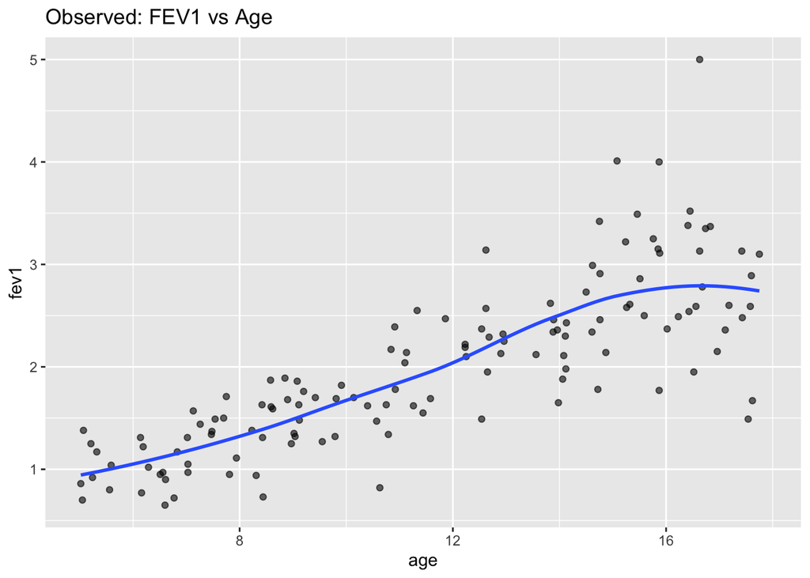

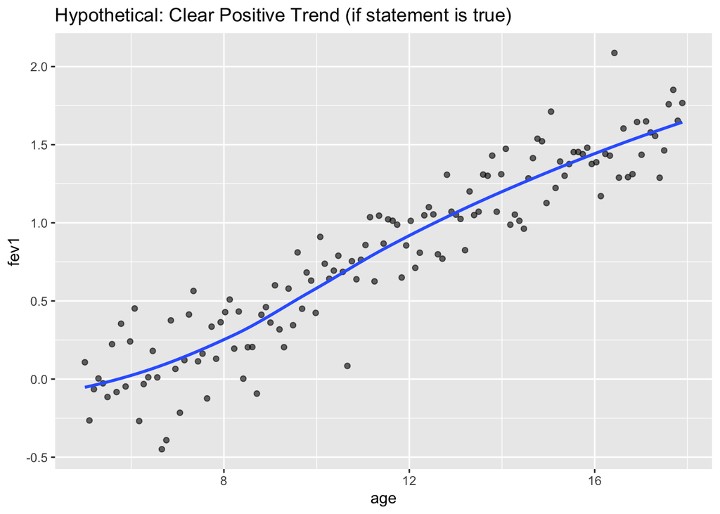

```r
premise3_fn(dataset)
```

Execute each of your function and show that the produce the expected output.

## Part 5

Describe one alternative to the primary statement “FEV1 values in children are higher in older children relative to younger children”.

Create a fault tree for the alternative outcome describing how the alternative outcome could be realized in the data even if the primary statement were true.

Your fault tree should be created as a separate image and does not need to be created in R. Upload the image of the fault tree to Canvas.

*Older children do not show higher FEV1 than younger children (null or inverse association), despite the biological expectation.*

```r
library(DiagrammeR)

ft <- DiagrammeR::grViz("
digraph ft {
  graph [rankdir=TB, fontsize=10]
  node [shape=box, style=rounded]
  edge [arrowhead=none]

  T [label='Top event: Expected positive age → FEV1 not observed']

  M [label='Measurement issues']
  S [label='Specification/model issues']
  L [label='Selection/behavioral factors']
  D [label='Data handling choices']
  E [label='Effect modification']

  T -> M; T -> S; T -> L; T -> D; T -> E

  M1 [label='Spirometry calibration/technique errors']; M -> M1
  M2 [label='Height/size not captured properly'];    M -> M2

  S1 [label='Omitted confounder (height, meds)']; S -> S1
  S2 [label='Nonlinearity or threshold'];         S -> S2

  L1 [label='Older kids on controller meds lower FEV1 variability']; L -> L1

  D1 [label='Transform/winsor choices']; D -> D1
  D2 [label='Missing not at random'];    D -> D2

  E1 [label='Effect differs by sex or allergy'];  E -> E1
}
")

ft
```

[interactive chart not shown]

```r
svg_txt <- DiagrammeRsvg::export_svg(ft)
rsvg::rsvg_png(charToRaw(svg_txt), file = "fault_tree.png", width = 1200, height = 900)
message("Saved fault_tree.png in the project directory.")
```